# finalproject

step 1 Scatter plots Matrix see the relationship between Response Variables and Explanatory Variables and the scatter plots matrix shows that x3 and X5, x3 and x6, x3 and x7, x5 and x7, x6 and x7 have important interaction.

```r
library(MASS)
df = read.csv("D:/Users/Haonan/Desktop/stat 350/project/real estate.csv")[,-1]
head(df)
```

```
##   X1.transaction.date X2.house.age X3.distance.to.the.nearest.MRT.station
## 1            2012.917         32.0                               84.87882
## 2            2012.917         19.5                              306.59470
## 3            2013.583         13.3                              561.98450
## 4            2013.500         13.3                              561.98450
## 5            2012.833          5.0                              390.56840
## 6            2012.667          7.1                             2175.03000
##   X4.number.of.convenience.stores X5.latitude X6.longitude
## 1                              10    24.98298     121.5402
## 2                               9    24.98034     121.5395
## 3                               5    24.98746     121.5439
## 4                               5    24.98746     121.5439
## 5                               5    24.97937     121.5425
## 6                               3    24.96305     121.5125
##   X7.distance.to.nearest.School Y.house.price.of.unit.area
## 1                            81                       37.9
## 2                            72                       42.2
## 3                            69                       47.3
## 4                            60                       54.8
## 5                            73                       43.1
## 6                            85                       32.1
```

```r
summary(df)
```

```
##  X1.transaction.date  X2.house.age    X3.distance.to.the.nearest.MRT.station
##  Min.   :2013        Min.   : 0.000   Min.   :  23.38
##  1st Qu.:2013        1st Qu.: 9.025   1st Qu.: 289.32
##  Median :2013        Median :16.100   Median : 492.23
##  Mean   :2013        Mean   :17.713   Mean   :1083.89
##  3rd Qu.:2013        3rd Qu.:28.150   3rd Qu.:1454.28
##  Max.   :2014        Max.   :43.800   Max.   :6488.02
##  X4.number.of.convenience.stores  X5.latitude     X6.longitude
##  Min.   : 0.000                  Min.   :24.93   Min.   :121.5
##  1st Qu.: 1.000                  1st Qu.:24.96   1st Qu.:121.5
##  Median : 4.000                  Median :24.97   Median :121.5
##  Mean   : 4.094                  Mean   :24.97   Mean   :121.5
##  3rd Qu.: 6.000                  3rd Qu.:24.98   3rd Qu.:121.5
##  Max.   :10.000                  Max.   :25.01   Max.   :121.6
##  X7.distance.to.nearest.School Y.house.price.of.unit.area
##  Min.   :  5.00                Min.   :  7.60
##  1st Qu.: 69.00                1st Qu.: 27.70
##  Median : 78.00                Median : 38.45
##  Mean   : 77.33                Mean   : 37.98
##  3rd Qu.: 86.00                3rd Qu.: 46.60
##  Max.   :107.00                Max.   :117.50
```

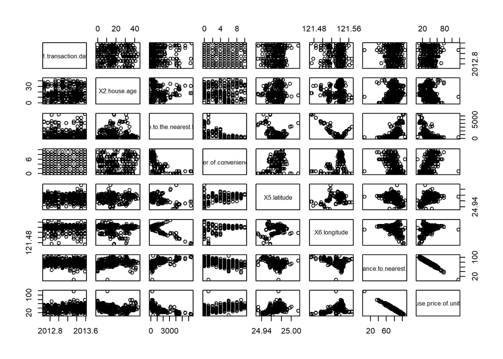

```r
pairs(df)
```

step 2 variable selection Q-Q plot shows residuals may not follow Normal Distribution, we try to use square root transformation to fit it better.

```r
M0 = lm(df$Y.house.price.of.unit.area ~ df$X1.transaction.date + df$X2.house.age +
          df$X3.distance.to.the.nearest.MRT.station + df$X4.number.of.convenience.stores +
          df$X5.latitude + df$X6.longitude + df$X7.distance.to.nearest.School +
          df$X3.distance.to.the.nearest.MRT.station * df$X6.longitude +
          df$X3.distance.to.the.nearest.MRT.station * df$X5.latitude +
          df$X3.distance.to.the.nearest.MRT.station * df$X7.distance.to.nearest.School +
          df$X5.latitude * df$X7.distance.to.nearest.School +
          df$X6.longitude * df$X7.distance.to.nearest.School)
summary(M0)
```

```
##
## Call:
## lm(formula = df$Y.house.price.of.unit.area ~ df$X1.transaction.date +
##     df$X2.house.age + df$X3.distance.to.the.nearest.MRT.station +
##     df$X4.number.of.convenience.stores + df$X5.latitude + df$X6.longitude +
##     df$X7.distance.to.nearest.School + df$X3.distance.to.the.nearest.MRT.station *
##     df$X6.longitude + df$X3.distance.to.the.nearest.MRT.station *
##     df$X5.latitude + df$X3.distance.to.the.nearest.MRT.station *
##     df$X7.distance.to.nearest.School + df$X5.latitude * df$X7.distance.to.nearest.School +
##     df$X6.longitude * df$X7.distance.to.nearest.School)
##
## Residuals:
##     Min      1Q  Median      3Q     Max
## -6.6805 -2.4449  0.1552  2.3528  8.2491
##
## Coefficients:
##                                                                              Estimate
## (Intercept)                                                                 3.204e+04
## df$X1.transaction.date                                                      1.278e+00
## df$X2.house.age                                                            -4.389e-02
## df$X3.distance.to.the.nearest.MRT.station                                   1.463e+00
## df$X4.number.of.convenience.stores                                          1.612e-01
## df$X5.latitude                                                              1.585e+02
## df$X6.longitude                                                            -3.164e+02
## df$X7.distance.to.nearest.School                                           -4.646e+02
## df$X3.distance.to.the.nearest.MRT.station:df$X6.longitude                  -1.054e-02
## df$X3.distance.to.the.nearest.MRT.station:df$X5.latitude                   -7.638e-03
## df$X3.distance.to.the.nearest.MRT.station:df$X7.distance.to.nearest.School  8.682e-05
## df$X5.latitude:df$X7.distance.to.nearest.School                            -9.801e-01
## df$X6.longitude:df$X7.distance.to.nearest.School                            4.016e+00
##                                                                            Std. Error
## (Intercept)                                                                 2.057e+04
## df$X1.transaction.date                                                      5.520e-01
## df$X2.house.age                                                             1.446e-02
## df$X3.distance.to.the.nearest.MRT.station                                   1.287e+00
## df$X4.number.of.convenience.stores                                          7.573e-02
## df$X5.latitude                                                              1.261e+02
## df$X6.longitude                                                             1.744e+02
## df$X7.distance.to.nearest.School                                            2.491e+02
## df$X3.distance.to.the.nearest.MRT.station:df$X6.longitude                   1.088e-02
```

[output cut: 37 more lines]

```
## df$X4.number.of.convenience.stores                                         *
## df$X5.latitude
## df$X6.longitude                                                            .
## df$X7.distance.to.nearest.School                                           .
## df$X3.distance.to.the.nearest.MRT.station:df$X6.longitude
## df$X3.distance.to.the.nearest.MRT.station:df$X5.latitude
## df$X3.distance.to.the.nearest.MRT.station:df$X7.distance.to.nearest.School ***
## df$X5.latitude:df$X7.distance.to.nearest.School
## df$X6.longitude:df$X7.distance.to.nearest.School                           .
## ---
## Signif. codes:  0 '***' 0.001 '**' 0.01 '*' 0.05 '.' 0.1 ' ' 1
##
## Residual standard error: 3.054 on 401 degrees of freedom
## Multiple R-squared:  0.9511, Adjusted R-squared:  0.9496
## F-statistic: 649.6 on 12 and 401 DF,  p-value: < 2.2e-16
```

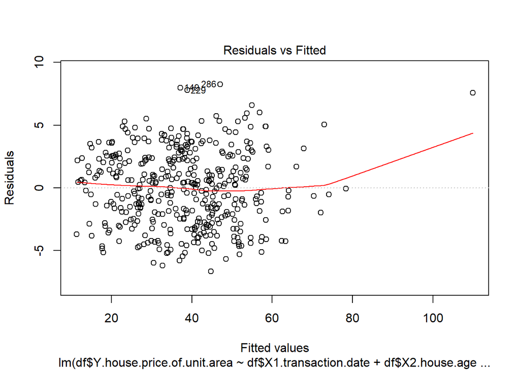

```r
plot(M0,1)
```

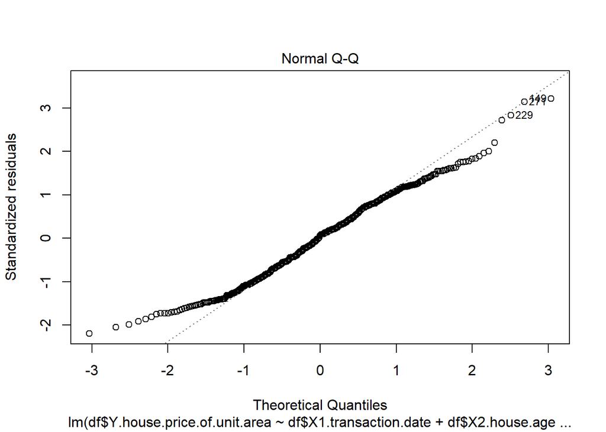

```r
plot(M0,2)
```

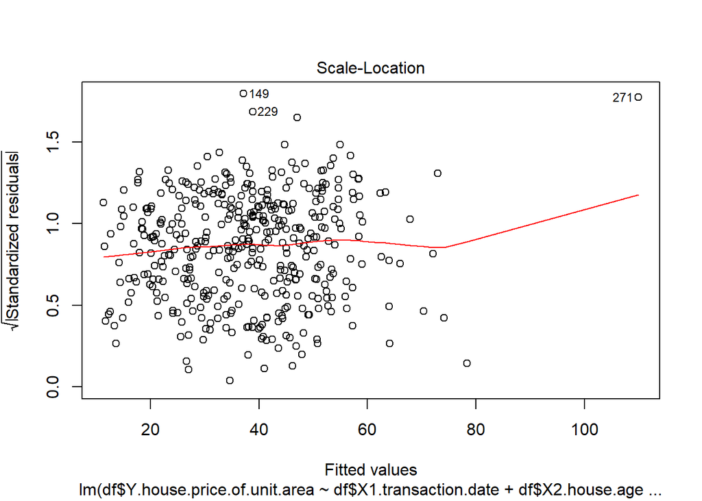

```r
plot(M0,3)
```

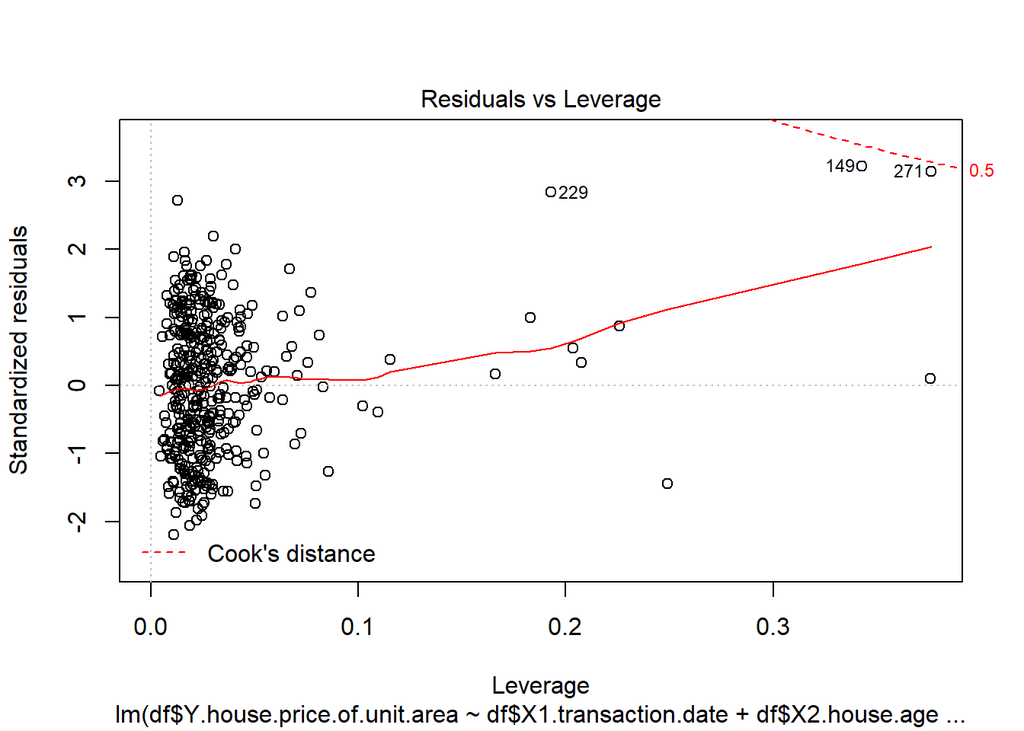

```r
plot(M0,5)
```

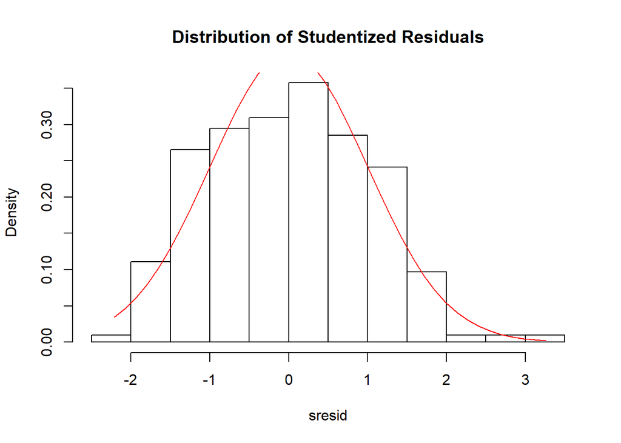

```r
sresid = studres(M0)
hist(sresid, freq=FALSE,main="Distribution of Studentized Residuals")
xfit<-seq(min(sresid),max(sresid),length=40)
yfit<-dnorm(xfit)
lines(xfit, yfit,col = "red")
```

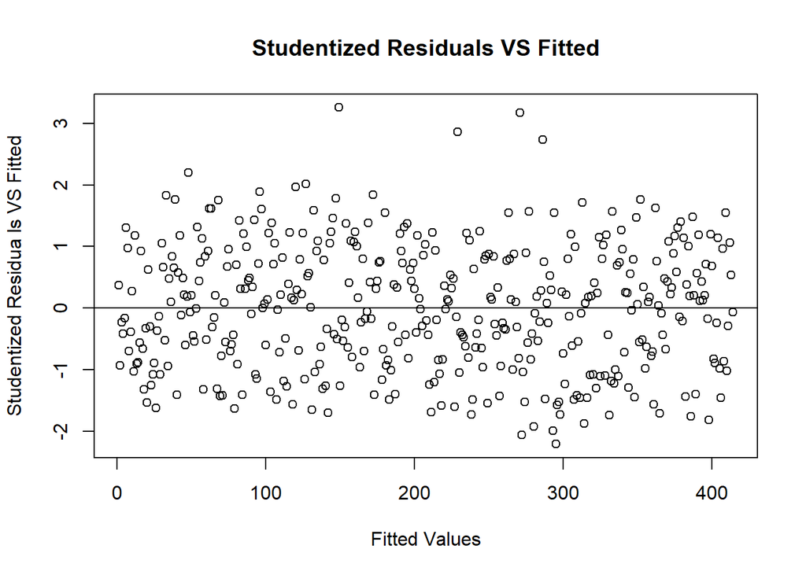

```r
plot(sresid, main = "Studentized Residuals VS Fitted", ylab = "Studentized Residua ls VS Fitted", xlab = "Fitted Values")
abline(0,0)
```

```r
M0 = lm(sqrt(df$Y.house.price.of.unit.area) ~ df$X1.transaction.date + df$X2.house.age +
          df$X3.distance.to.the.nearest.MRT.station + df$X4.number.of.convenience.stores +
          df$X5.latitude + df$X6.longitude + df$X7.distance.to.nearest.School +
          df$X3.distance.to.the.nearest.MRT.station * df$X6.longitude +
          df$X3.distance.to.the.nearest.MRT.station * df$X5.latitude +
          df$X3.distance.to.the.nearest.MRT.station * df$X7.distance.to.nearest.School +
          df$X5.latitude * df$X7.distance.to.nearest.School +
          df$X6.longitude * df$X7.distance.to.nearest.School)
summary(M0)
```

```
##
## Call:
## lm(formula = sqrt(df$Y.house.price.of.unit.area) ~ df$X1.transaction.date +
##     df$X2.house.age + df$X3.distance.to.the.nearest.MRT.station +
##     df$X4.number.of.convenience.stores + df$X5.latitude + df$X6.longitude +
##     df$X7.distance.to.nearest.School + df$X3.distance.to.the.nearest.MRT.station *
##     df$X6.longitude + df$X3.distance.to.the.nearest.MRT.station *
##     df$X5.latitude + df$X3.distance.to.the.nearest.MRT.station *
##     df$X7.distance.to.nearest.School + df$X5.latitude * df$X7.distance.to.nearest.School +
##     df$X6.longitude * df$X7.distance.to.nearest.School)
##
## Residuals:
##      Min       1Q   Median       3Q      Max
## -1.25570 -0.18108  0.00931  0.19990  0.70294
##
## Coefficients:
##                                                                              Estimate
## (Intercept)                                                                 1.268e+03
## df$X1.transaction.date                                                      9.739e-02
## df$X2.house.age                                                            -4.815e-03
## df$X3.distance.to.the.nearest.MRT.station                                   2.497e-01
## df$X4.number.of.convenience.stores                                          1.536e-02
## df$X5.latitude                                                             -2.066e+01
## df$X6.longitude                                                            -7.704e+00
## df$X7.distance.to.nearest.School                                           -2.821e+01
## df$X3.distance.to.the.nearest.MRT.station:df$X6.longitude                  -1.541e-03
## df$X3.distance.to.the.nearest.MRT.station:df$X5.latitude                   -2.508e-03
## df$X3.distance.to.the.nearest.MRT.station:df$X7.distance.to.nearest.School  4.731e-07
## df$X5.latitude:df$X7.distance.to.nearest.School                             4.089e-01
## df$X6.longitude:df$X7.distance.to.nearest.School                            1.475e-01
##                                                                            Std. Error
## (Intercept)                                                                 1.752e+03
## df$X1.transaction.date                                                      4.701e-02
## df$X2.house.age                                                             1.232e-03
## df$X3.distance.to.the.nearest.MRT.station                                   1.096e-01
## df$X4.number.of.convenience.stores                                          6.450e-03
## df$X5.latitude                                                              1.074e+01
## df$X6.longitude                                                             1.485e+01
## df$X7.distance.to.nearest.School                                            2.121e+01
## df$X3.distance.to.the.nearest.MRT.station:df$X6.longitude                   9.265e-04
```

[output cut: 37 more lines]

```
## df$X4.number.of.convenience.stores                                         *
## df$X5.latitude                                                             .
## df$X6.longitude
## df$X7.distance.to.nearest.School
## df$X3.distance.to.the.nearest.MRT.station:df$X6.longitude                  .
## df$X3.distance.to.the.nearest.MRT.station:df$X5.latitude                   *
## df$X3.distance.to.the.nearest.MRT.station:df$X7.distance.to.nearest.School
## df$X5.latitude:df$X7.distance.to.nearest.School                            **
## df$X6.longitude:df$X7.distance.to.nearest.School
## ---
## Signif. codes:  0 '***' 0.001 '**' 0.01 '*' 0.05 '.' 0.1 ' ' 1
##
## Residual standard error: 0.2601 on 401 degrees of freedom
## Multiple R-squared:  0.9478, Adjusted R-squared:  0.9463
## F-statistic: 607.3 on 12 and 401 DF,  p-value: < 2.2e-16
```

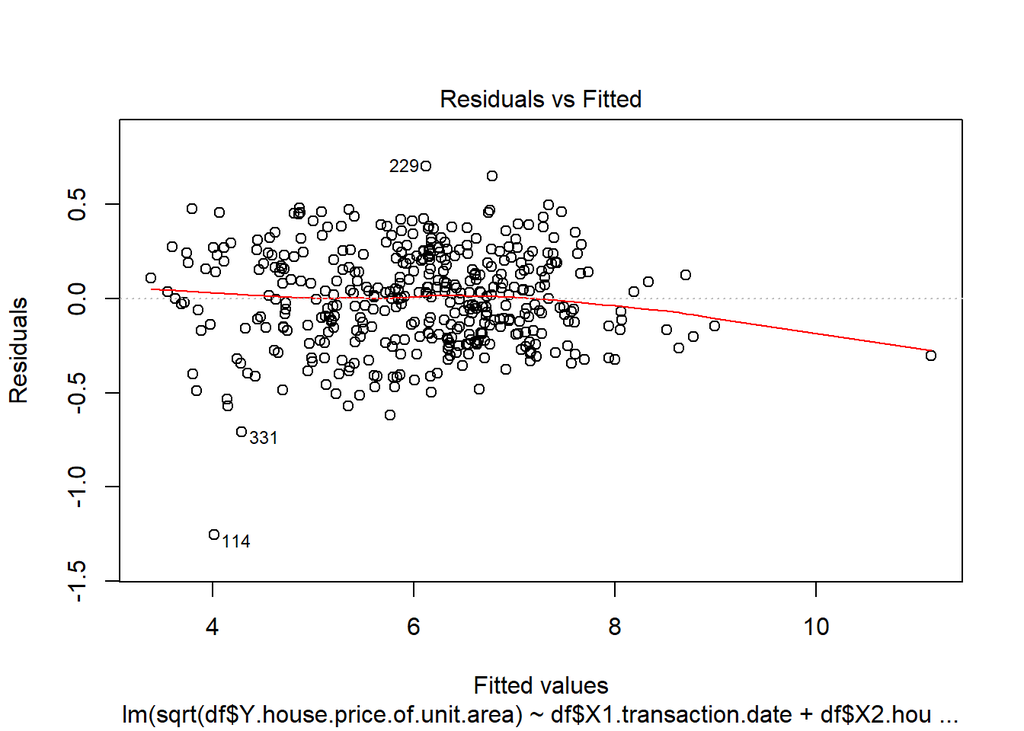

```r
plot(M0,1)
```

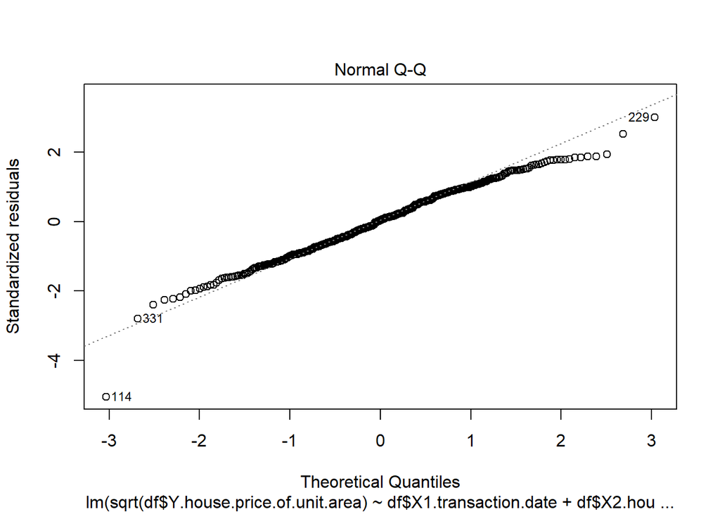

```r
plot(M0,2)
```

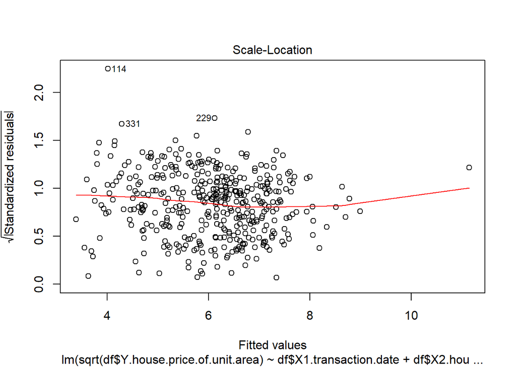

```r
plot(M0,3)
```

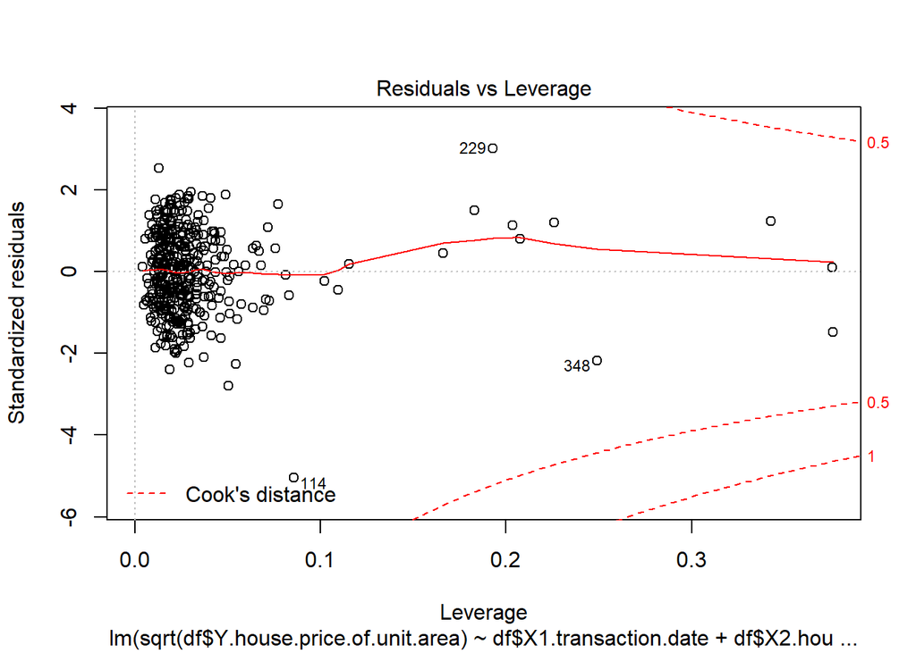

```r
plot(M0,5)
```

```r
df[c(114,229,331),]
```

```
##     X1.transaction.date X2.house.age X3.distance.to.the.nearest.MRT.station
## 114            2013.333         14.8                               393.2606
## 229            2013.417         11.9                              3171.3290
## 331            2013.083         32.0                              1156.7770
##     X4.number.of.convenience.stores X5.latitude X6.longitude
## 114                               6    24.96172     121.5381
## 229                               0    25.00115     121.5178
## 331                               0    24.94935     121.5305
##     X7.distance.to.nearest.School Y.house.price.of.unit.area
## 114                           107                        7.6
## 229                            73                       46.6
## 331                            96                       12.8
```

```r
df = df[-c(114),]
M0 = lm(sqrt(df$Y.house.price.of.unit.area) ~ df$X1.transaction.date + df$X2.house.age +
          df$X3.distance.to.the.nearest.MRT.station + df$X4.number.of.convenience.stores +
          df$X5.latitude + df$X6.longitude + df$X7.distance.to.nearest.School +
          df$X3.distance.to.the.nearest.MRT.station * df$X6.longitude +
          df$X3.distance.to.the.nearest.MRT.station * df$X5.latitude +
          df$X3.distance.to.the.nearest.MRT.station * df$X7.distance.to.nearest.School +
          df$X5.latitude * df$X7.distance.to.nearest.School +
          df$X6.longitude * df$X7.distance.to.nearest.School)
summary(M0)
```

```
##
## Call:
## lm(formula = sqrt(df$Y.house.price.of.unit.area) ~ df$X1.transaction.date +
##     df$X2.house.age + df$X3.distance.to.the.nearest.MRT.station +
##     df$X4.number.of.convenience.stores + df$X5.latitude + df$X6.longitude +
##     df$X7.distance.to.nearest.School + df$X3.distance.to.the.nearest.MRT.station *
##     df$X6.longitude + df$X3.distance.to.the.nearest.MRT.station *
##     df$X5.latitude + df$X3.distance.to.the.nearest.MRT.station *
##     df$X7.distance.to.nearest.School + df$X5.latitude * df$X7.distance.to.nearest.School +
##     df$X6.longitude * df$X7.distance.to.nearest.School)
##
## Residuals:
##      Min       1Q   Median       3Q      Max
## -0.75665 -0.17776  0.00562  0.19172  0.67198
##
## Coefficients:
##                                                                              Estimate
## (Intercept)                                                                 1.741e+03
## df$X1.transaction.date                                                      1.119e-01
## df$X2.house.age                                                            -5.453e-03
## df$X3.distance.to.the.nearest.MRT.station                                   3.200e-01
## df$X4.number.of.convenience.stores                                          1.871e-02
## df$X5.latitude                                                             -1.092e+01
## df$X6.longitude                                                            -1.384e+01
## df$X7.distance.to.nearest.School                                           -3.465e+01
## df$X3.distance.to.the.nearest.MRT.station:df$X6.longitude                  -2.190e-03
## df$X3.distance.to.the.nearest.MRT.station:df$X5.latitude                   -2.164e-03
## df$X3.distance.to.the.nearest.MRT.station:df$X7.distance.to.nearest.School -1.210e-07
## df$X5.latitude:df$X7.distance.to.nearest.School                             2.767e-01
## df$X6.longitude:df$X7.distance.to.nearest.School                            2.277e-01
##                                                                            Std. Error
## (Intercept)                                                                 1.700e+03
## df$X1.transaction.date                                                      4.563e-02
## df$X2.house.age                                                             1.200e-03
## df$X3.distance.to.the.nearest.MRT.station                                   1.070e-01
## df$X4.number.of.convenience.stores                                          6.282e-03
## df$X5.latitude                                                              1.057e+01
## df$X6.longitude                                                             1.444e+01
## df$X7.distance.to.nearest.School                                            2.059e+01
## df$X3.distance.to.the.nearest.MRT.station:df$X6.longitude                   9.063e-04
```

[output cut: 37 more lines]

```
## df$X4.number.of.convenience.stores                                         **
## df$X5.latitude
## df$X6.longitude
## df$X7.distance.to.nearest.School                                           .
## df$X3.distance.to.the.nearest.MRT.station:df$X6.longitude                  *
## df$X3.distance.to.the.nearest.MRT.station:df$X5.latitude                   *
## df$X3.distance.to.the.nearest.MRT.station:df$X7.distance.to.nearest.School
## df$X5.latitude:df$X7.distance.to.nearest.School                            *
## df$X6.longitude:df$X7.distance.to.nearest.School
## ---
## Signif. codes:  0 '***' 0.001 '**' 0.01 '*' 0.05 '.' 0.1 ' ' 1
##
## Residual standard error: 0.252 on 400 degrees of freedom
## Multiple R-squared:  0.9501, Adjusted R-squared:  0.9486
## F-statistic: 634.8 on 12 and 400 DF,  p-value: < 2.2e-16
```

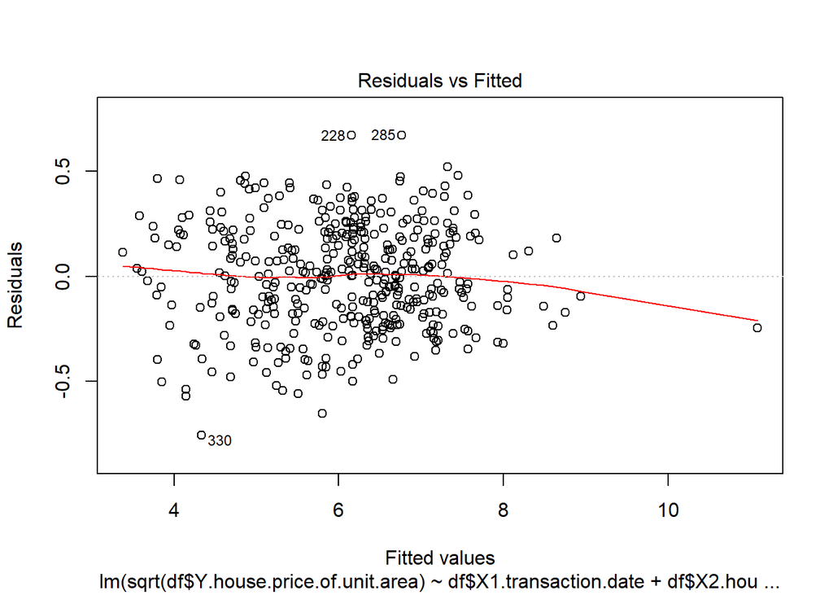

```r
plot(M0,1)
```

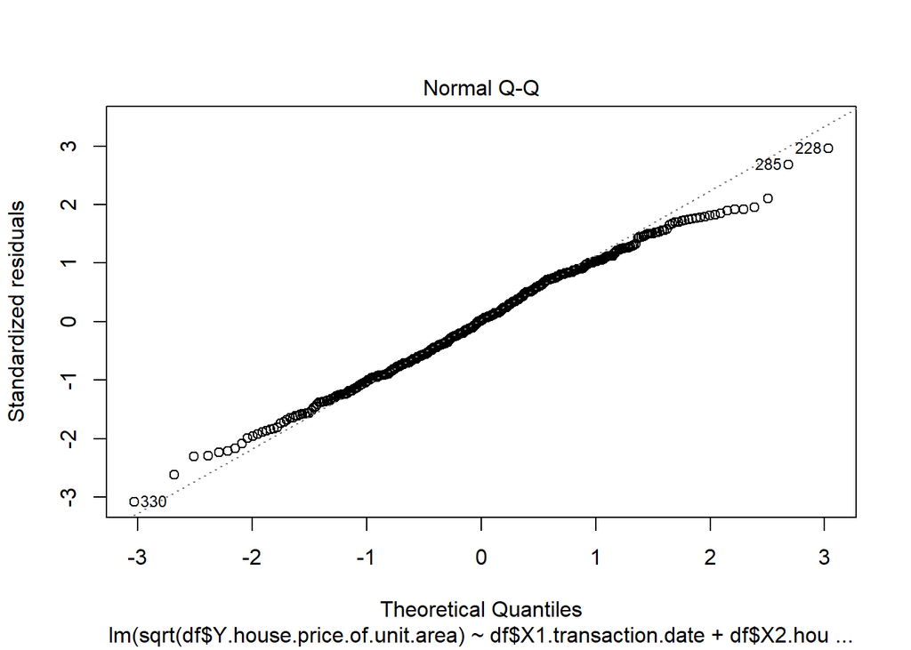

```r
plot(M0,2)
```

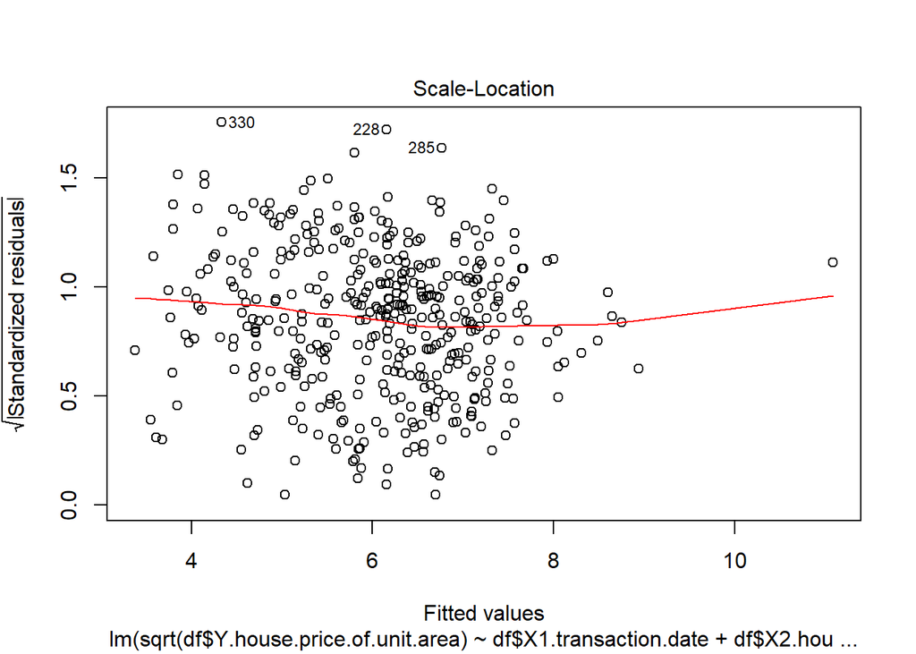

```r
plot(M0,3)
```

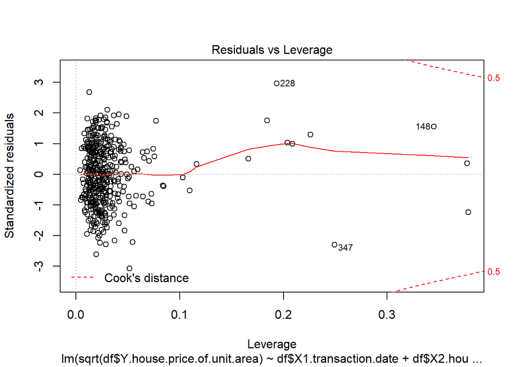

```r
plot(M0,5)
```

```r
M1 =  lm(sqrt(df$Y.house.price.of.unit.area) ~ df$X1.transaction.date + df$X2.house.age +
           df$X3.distance.to.the.nearest.MRT.station + df$X4.number.of.convenience.stores +                                            df$X7.distance.to.nearest.School +
           df$X3.distance.to.the.nearest.MRT.station * df$X6.longitude +
           df$X3.distance.to.the.nearest.MRT.station * df$X5.latitude +
           df$X5.latitude * df$X7.distance.to.nearest.School)
summary(M1)
```

```
##
## Call:
## lm(formula = sqrt(df$Y.house.price.of.unit.area) ~ df$X1.transaction.date +
##     df$X2.house.age + df$X3.distance.to.the.nearest.MRT.station +
##     df$X4.number.of.convenience.stores + df$X7.distance.to.nearest.School +
##     df$X3.distance.to.the.nearest.MRT.station * df$X6.longitude +
##     df$X3.distance.to.the.nearest.MRT.station * df$X5.latitude +
##     df$X5.latitude * df$X7.distance.to.nearest.School)
##
## Residuals:
##      Min       1Q   Median       3Q      Max
## -0.75156 -0.18107  0.00751  0.19425  0.73826
##
## Coefficients:
##                                                             Estimate Std. Error
## (Intercept)                                               -2.634e+02  3.137e+02
## df$X1.transaction.date                                     1.109e-01  4.517e-02
## df$X2.house.age                                           -5.057e-03  1.174e-03
## df$X3.distance.to.the.nearest.MRT.station                  2.087e-01  7.729e-02
## df$X4.number.of.convenience.stores                         1.581e-02  6.004e-03
## df$X7.distance.to.nearest.School                          -9.423e+00  3.020e+00
## df$X6.longitude                                            4.233e+00  1.911e+00
## df$X5.latitude                                            -1.853e+01  9.197e+00
## df$X3.distance.to.the.nearest.MRT.station:df$X6.longitude -1.257e-03  6.620e-04
## df$X3.distance.to.the.nearest.MRT.station:df$X5.latitude  -2.244e-03  9.548e-04
## df$X7.distance.to.nearest.School:df$X5.latitude            3.747e-01  1.210e-01
##                                                           t value Pr(>|t|)
## (Intercept)                                                -0.840  0.40150
## df$X1.transaction.date                                      2.455  0.01452 *
## df$X2.house.age                                            -4.307 2.08e-05 ***
## df$X3.distance.to.the.nearest.MRT.station                   2.700  0.00722 **
## df$X4.number.of.convenience.stores                          2.633  0.00879 **
## df$X7.distance.to.nearest.School                           -3.120  0.00194 **
## df$X6.longitude                                             2.214  0.02736 *
## df$X5.latitude                                             -2.015  0.04458 *
## df$X3.distance.to.the.nearest.MRT.station:df$X6.longitude  -1.900  0.05821 .
## df$X3.distance.to.the.nearest.MRT.station:df$X5.latitude   -2.351  0.01923 *
## df$X7.distance.to.nearest.School:df$X5.latitude             3.098  0.00209 **
## ---
## Signif. codes:  0 '***' 0.001 '**' 0.01 '*' 0.05 '.' 0.1 ' ' 1
##
## Residual standard error: 0.2522 on 402 degrees of freedom
## Multiple R-squared:  0.9498, Adjusted R-squared:  0.9485
## F-statistic: 760.5 on 10 and 402 DF,  p-value: < 2.2e-16
```

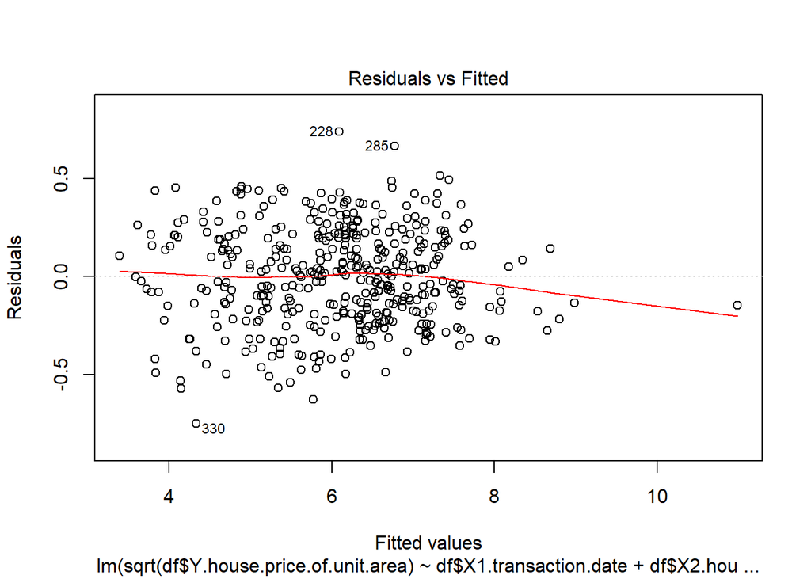

```r
plot(M1,1)
```

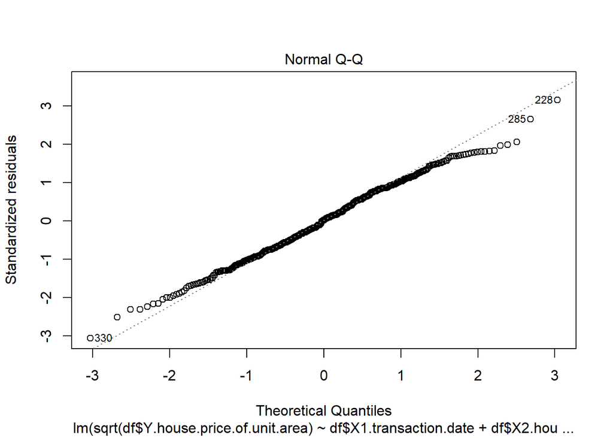

```r
plot(M1,2)
```

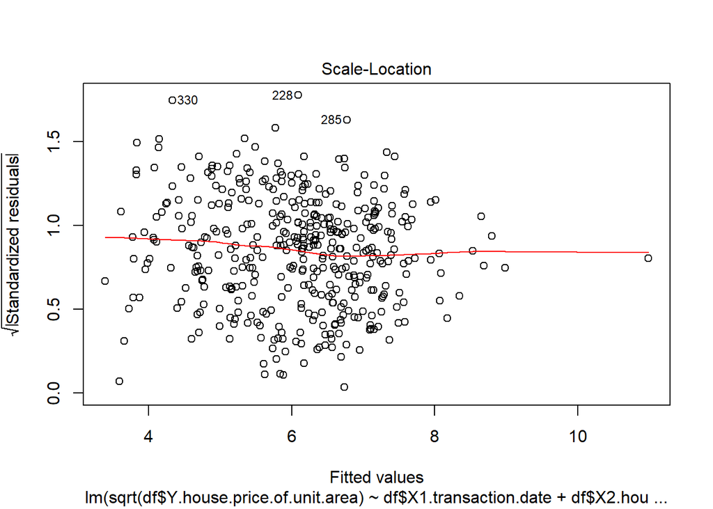

```r
plot(M1,3)
```

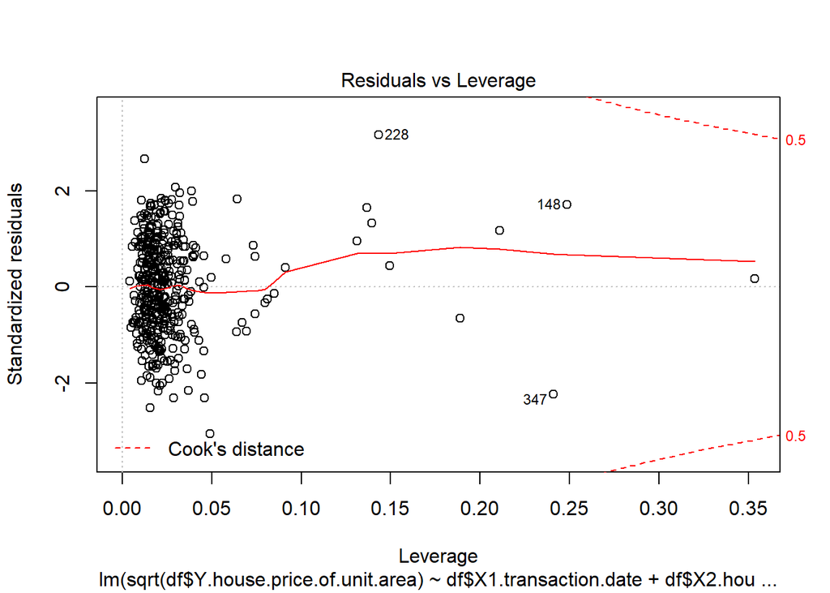

```r
plot(M1,5)
```

step 3 Stepwise Regression forward(X7 X3 X5 X4 X2 X1 X3*X5 X5*X7)

```r
inter = lm(sqrt(Y.house.price.of.unit.area) ~1, data=df)
forward = step(inter, direction='forward', scope=formula(M0), trace=0)
forward$anova
```

```
##                                                         Step Df    Deviance
## 1                                                            NA          NA
## 2                         + df$X7.distance.to.nearest.School -1 467.1223628
## 3                + df$X3.distance.to.the.nearest.MRT.station -1  11.4450116
## 4                                           + df$X5.latitude -1   2.0408760
## 5                       + df$X4.number.of.convenience.stores -1   0.8774756
## 6                                          + df$X2.house.age -1   0.9185490
## 7                                   + df$X1.transaction.date -1   0.3239594
## 8 + df$X3.distance.to.the.nearest.MRT.station:df$X5.latitude -1   0.2009379
## 9          + df$X5.latitude:df$X7.distance.to.nearest.School -1   0.5251350
##   Resid. Df Resid. Dev         AIC
## 1       412  509.35654    88.60637
## 2       411   42.23418  -937.72995
## 3       410   30.78917 -1066.26559
## 4       409   28.74829 -1092.59102
## 5       408   27.87081 -1103.39329
## 6       407   26.95227 -1115.23404
## 7       406   26.62831 -1118.22827
## 8       405   26.42737 -1119.35659
## 9       404   25.90223 -1125.64590
```

```r
round(forward$coefficients,5)
```

```
##                                              (Intercept)
##                                                178.78210
##                         df$X7.distance.to.nearest.School
##                                                 -8.61508
##                df$X3.distance.to.the.nearest.MRT.station
##                                                  0.06585
##                                           df$X5.latitude
##                                                -15.60489
##                       df$X4.number.of.convenience.stores
##                                                  0.01924
##                                          df$X2.house.age
##                                                 -0.00485
##                                   df$X1.transaction.date
##                                                  0.11046
## df$X3.distance.to.the.nearest.MRT.station:df$X5.latitude
##                                                 -0.00264
##          df$X7.distance.to.nearest.School:df$X5.latitude
##                                                  0.34229
```

```r
inter = lm(sqrt(Y.house.price.of.unit.area) ~1, data=df)
forward = step(inter, direction='forward', scope=formula(M0), trace=0)
forward$anova
```

```
##                                                         Step Df    Deviance
## 1                                                            NA          NA
## 2                         + df$X7.distance.to.nearest.School -1 467.1223628
## 3                + df$X3.distance.to.the.nearest.MRT.station -1  11.4450116
## 4                                           + df$X5.latitude -1   2.0408760
## 5                       + df$X4.number.of.convenience.stores -1   0.8774756
## 6                                          + df$X2.house.age -1   0.9185490
## 7                                   + df$X1.transaction.date -1   0.3239594
## 8 + df$X3.distance.to.the.nearest.MRT.station:df$X5.latitude -1   0.2009379
## 9          + df$X5.latitude:df$X7.distance.to.nearest.School -1   0.5251350
##   Resid. Df Resid. Dev         AIC
## 1       412  509.35654    88.60637
## 2       411   42.23418  -937.72995
## 3       410   30.78917 -1066.26559
## 4       409   28.74829 -1092.59102
## 5       408   27.87081 -1103.39329
## 6       407   26.95227 -1115.23404
## 7       406   26.62831 -1118.22827
## 8       405   26.42737 -1119.35659
## 9       404   25.90223 -1125.64590
```

```r
round(forward$coefficients,5)
```

```
##                                              (Intercept)
##                                                178.78210
##                         df$X7.distance.to.nearest.School
##                                                 -8.61508
##                df$X3.distance.to.the.nearest.MRT.station
##                                                  0.06585
##                                           df$X5.latitude
##                                                -15.60489
##                       df$X4.number.of.convenience.stores
##                                                  0.01924
##                                          df$X2.house.age
##                                                 -0.00485
##                                   df$X1.transaction.date
##                                                  0.11046
## df$X3.distance.to.the.nearest.MRT.station:df$X5.latitude
##                                                 -0.00264
##          df$X7.distance.to.nearest.School:df$X5.latitude
##                                                  0.34229
```

Direction Step wise Selection(X7 X3 X5 X4 X2 X1 X3*X5 X5*X7)

```r
inter = lm(sqrt(Y.house.price.of.unit.area) ~1, data=df)
both = step(inter, direction='both', scope=formula(M0), trace=0)
both$anova
```

```
##                                                         Step Df    Deviance
## 1                                                            NA          NA
## 2                         + df$X7.distance.to.nearest.School -1 467.1223628
## 3                + df$X3.distance.to.the.nearest.MRT.station -1  11.4450116
## 4                                           + df$X5.latitude -1   2.0408760
## 5                       + df$X4.number.of.convenience.stores -1   0.8774756
## 6                                          + df$X2.house.age -1   0.9185490
## 7                                   + df$X1.transaction.date -1   0.3239594
## 8 + df$X3.distance.to.the.nearest.MRT.station:df$X5.latitude -1   0.2009379
## 9          + df$X5.latitude:df$X7.distance.to.nearest.School -1   0.5251350
##   Resid. Df Resid. Dev         AIC
## 1       412  509.35654    88.60637
## 2       411   42.23418  -937.72995
## 3       410   30.78917 -1066.26559
## 4       409   28.74829 -1092.59102
## 5       408   27.87081 -1103.39329
## 6       407   26.95227 -1115.23404
## 7       406   26.62831 -1118.22827
## 8       405   26.42737 -1119.35659
## 9       404   25.90223 -1125.64590
```

```r
round(both$coefficients,5)
```

```
##                                              (Intercept)
##                                                178.78210
##                         df$X7.distance.to.nearest.School
##                                                 -8.61508
##                df$X3.distance.to.the.nearest.MRT.station
##                                                  0.06585
##                                           df$X5.latitude
##                                                -15.60489
##                       df$X4.number.of.convenience.stores
##                                                  0.01924
##                                          df$X2.house.age
##                                                 -0.00485
##                                   df$X1.transaction.date
##                                                  0.11046
## df$X3.distance.to.the.nearest.MRT.station:df$X5.latitude
##                                                 -0.00264
##          df$X7.distance.to.nearest.School:df$X5.latitude
##                                                  0.34229
```

In step 3, we find out 2 more models which is M2 and M3 and we show them in step4.

step 4 The AIC and BIC model selection

```r
M0 = lm(sqrt(df$Y.house.price.of.unit.area) ~ df$X1.transaction.date + df$X2.house.age +
          df$X3.distance.to.the.nearest.MRT.station + df$X4.number.of.convenience.stores +
          df$X5.latitude + df$X6.longitude + df$X7.distance.to.nearest.School +
          df$X3.distance.to.the.nearest.MRT.station * df$X6.longitude +
          df$X3.distance.to.the.nearest.MRT.station * df$X5.latitude +
          df$X3.distance.to.the.nearest.MRT.station * df$X7.distance.to.nearest.School +
          df$X5.latitude * df$X7.distance.to.nearest.School +
          df$X6.longitude * df$X7.distance.to.nearest.School)

M1 =  lm(sqrt(df$Y.house.price.of.unit.area) ~ df$X1.transaction.date + df$X2.house.age +
           df$X3.distance.to.the.nearest.MRT.station + df$X4.number.of.convenience.stores +                                            df$X7.distance.to.nearest.School +
           df$X3.distance.to.the.nearest.MRT.station * df$X6.longitude +
           df$X3.distance.to.the.nearest.MRT.station * df$X5.latitude +
           df$X5.latitude * df$X7.distance.to.nearest.School)

M2 = lm(sqrt(df$Y.house.price.of.unit.area) ~ df$X1.transaction.date + df$X2.house.age +
          df$X3.distance.to.the.nearest.MRT.station + df$X4.number.of.convenience.stores +
          df$X5.latitude + df$X7.distance.to.nearest.School +
          df$X3.distance.to.the.nearest.MRT.station * df$X5.latitude +
          df$X5.latitude * df$X7.distance.to.nearest.School)
summary(M2)
```

```
##
## Call:
## lm(formula = sqrt(df$Y.house.price.of.unit.area) ~ df$X1.transaction.date +
##     df$X2.house.age + df$X3.distance.to.the.nearest.MRT.station +
##     df$X4.number.of.convenience.stores + df$X5.latitude + df$X7.distance.to.nearest.School +
##     df$X3.distance.to.the.nearest.MRT.station * df$X5.latitude +
##     df$X5.latitude * df$X7.distance.to.nearest.School)
##
## Residuals:
##      Min       1Q   Median       3Q      Max
## -0.76653 -0.19060  0.01097  0.19518  0.75165
##
## Coefficients:
##                                                            Estimate Std. Error
## (Intercept)                                               1.788e+02  2.454e+02
## df$X1.transaction.date                                    1.105e-01  4.532e-02
## df$X2.house.age                                          -4.852e-03  1.170e-03
## df$X3.distance.to.the.nearest.MRT.station                 6.585e-02  2.289e-02
## df$X4.number.of.convenience.stores                        1.924e-02  5.715e-03
## df$X5.latitude                                           -1.560e+01  9.109e+00
## df$X7.distance.to.nearest.School                         -8.615e+00  2.987e+00
## df$X3.distance.to.the.nearest.MRT.station:df$X5.latitude -2.643e-03  9.171e-04
## df$X5.latitude:df$X7.distance.to.nearest.School           3.423e-01  1.196e-01
##                                                          t value Pr(>|t|)
## (Intercept)                                                0.729 0.466673
## df$X1.transaction.date                                     2.438 0.015218 *
## df$X2.house.age                                           -4.146 4.13e-05 ***
## df$X3.distance.to.the.nearest.MRT.station                  2.877 0.004229 **
## df$X4.number.of.convenience.stores                         3.367 0.000832 ***
## df$X5.latitude                                            -1.713 0.087457 .
## df$X7.distance.to.nearest.School                          -2.885 0.004129 **
## df$X3.distance.to.the.nearest.MRT.station:df$X5.latitude  -2.882 0.004162 **
## df$X5.latitude:df$X7.distance.to.nearest.School            2.862 0.004430 **
## ---
## Signif. codes:  0 '***' 0.001 '**' 0.01 '*' 0.05 '.' 0.1 ' ' 1
##
## Residual standard error: 0.2532 on 404 degrees of freedom
## Multiple R-squared:  0.9491, Adjusted R-squared:  0.9481
## F-statistic: 942.6 on 8 and 404 DF,  p-value: < 2.2e-16
```

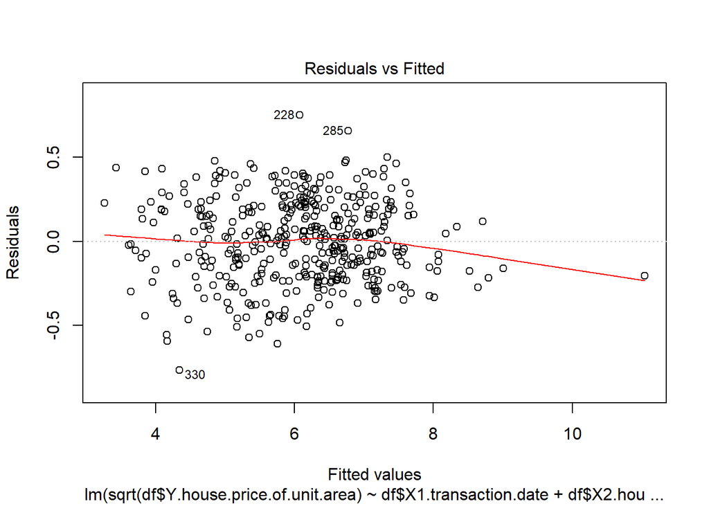

```r
plot(M2,1)
```

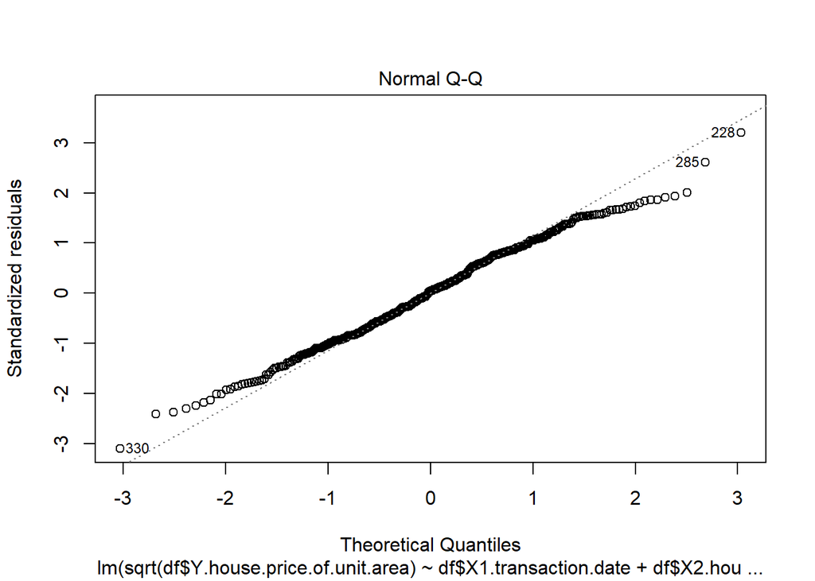

```r
plot(M2,2)
```

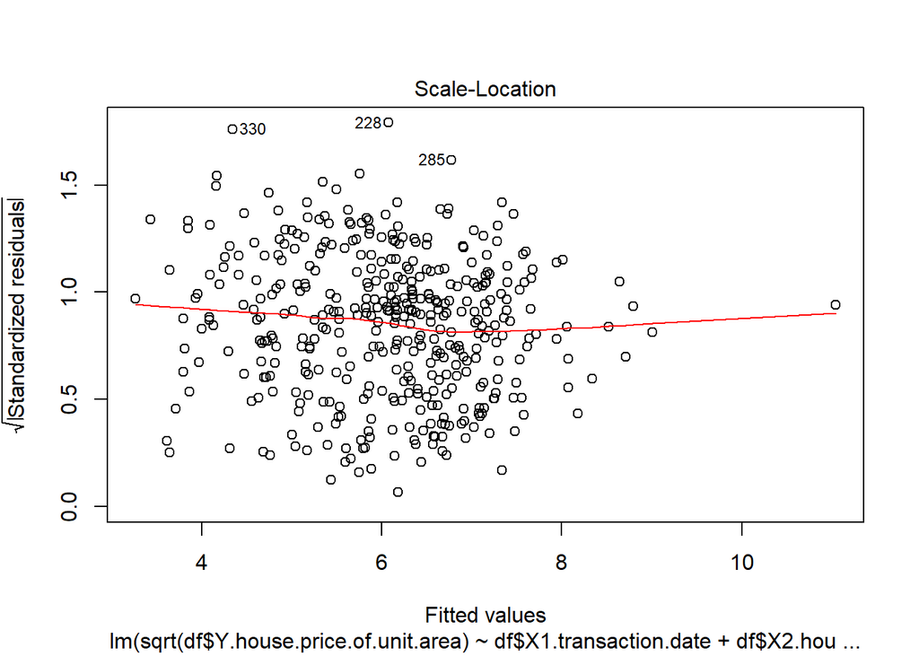

```r
plot(M2,3)
```

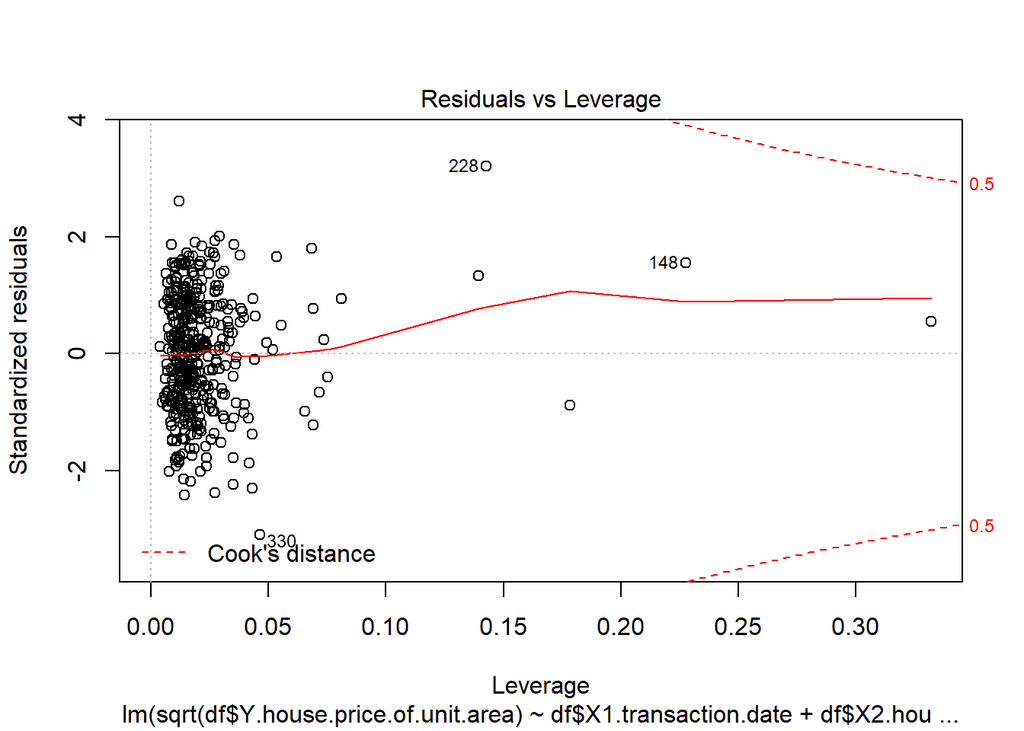

```r
plot(M2,5)
```

```r
M3 = lm(sqrt(df$Y.house.price.of.unit.area) ~ df$X1.transaction.date + df$X2.house.age +
          df$X3.distance.to.the.nearest.MRT.station + df$X4.number.of.convenience.stores +
          df$X5.latitude + df$X6.longitude + df$X7.distance.to.nearest.School +
          df$X3.distance.to.the.nearest.MRT.station * df$X6.longitude +
          df$X3.distance.to.the.nearest.MRT.station * df$X5.latitude +
          df$X5.latitude * df$X7.distance.to.nearest.School +
          df$X6.longitude * df$X7.distance.to.nearest.School)
summary(M3)
```

```
##
## Call:
## lm(formula = sqrt(df$Y.house.price.of.unit.area) ~ df$X1.transaction.date +
##     df$X2.house.age + df$X3.distance.to.the.nearest.MRT.station +
##     df$X4.number.of.convenience.stores + df$X5.latitude + df$X6.longitude +
##     df$X7.distance.to.nearest.School + df$X3.distance.to.the.nearest.MRT.station *
##     df$X6.longitude + df$X3.distance.to.the.nearest.MRT.station *
##     df$X5.latitude + df$X5.latitude * df$X7.distance.to.nearest.School +
##     df$X6.longitude * df$X7.distance.to.nearest.School)
##
## Residuals:
##      Min       1Q   Median       3Q      Max
## -0.75588 -0.17769  0.00529  0.19189  0.67363
##
## Coefficients:
##                                                             Estimate Std. Error
## (Intercept)                                                1.806e+03  1.334e+03
## df$X1.transaction.date                                     1.123e-01  4.510e-02
## df$X2.house.age                                           -5.451e-03  1.198e-03
## df$X3.distance.to.the.nearest.MRT.station                  3.183e-01  1.033e-01
## df$X4.number.of.convenience.stores                         1.873e-02  6.266e-03
## df$X5.latitude                                            -1.106e+01  1.031e+01
## df$X6.longitude                                           -1.435e+01  1.181e+01
## df$X7.distance.to.nearest.School                          -3.540e+01  1.656e+01
## df$X3.distance.to.the.nearest.MRT.station:df$X6.longitude -2.176e-03  8.764e-04
## df$X3.distance.to.the.nearest.MRT.station:df$X5.latitude  -2.164e-03  9.543e-04
## df$X5.latitude:df$X7.distance.to.nearest.School            2.788e-01  1.349e-01
## df$X6.longitude:df$X7.distance.to.nearest.School           2.334e-01  1.463e-01
##                                                           t value Pr(>|t|)
## (Intercept)                                                 1.353  0.17680
## df$X1.transaction.date                                      2.491  0.01313 *
## df$X2.house.age                                            -4.552 7.06e-06 ***
## df$X3.distance.to.the.nearest.MRT.station                   3.081  0.00220 **
## df$X4.number.of.convenience.stores                          2.989  0.00297 **
## df$X5.latitude                                             -1.073  0.28397
## df$X6.longitude                                            -1.216  0.22488
## df$X7.distance.to.nearest.School                           -2.137  0.03317 *
## df$X3.distance.to.the.nearest.MRT.station:df$X6.longitude  -2.483  0.01345 *
## df$X3.distance.to.the.nearest.MRT.station:df$X5.latitude   -2.268  0.02386 *
## df$X5.latitude:df$X7.distance.to.nearest.School             2.067  0.03936 *
## df$X6.longitude:df$X7.distance.to.nearest.School            1.595  0.11150
## ---
## Signif. codes:  0 '***' 0.001 '**' 0.01 '*' 0.05 '.' 0.1 ' ' 1
##
## Residual standard error: 0.2517 on 401 degrees of freedom
## Multiple R-squared:  0.9501, Adjusted R-squared:  0.9487
## F-statistic: 694.3 on 11 and 401 DF,  p-value: < 2.2e-16
```

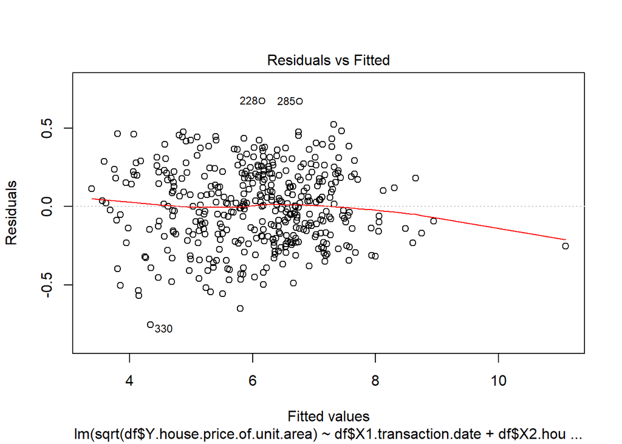

```r
plot(M3,1)
```

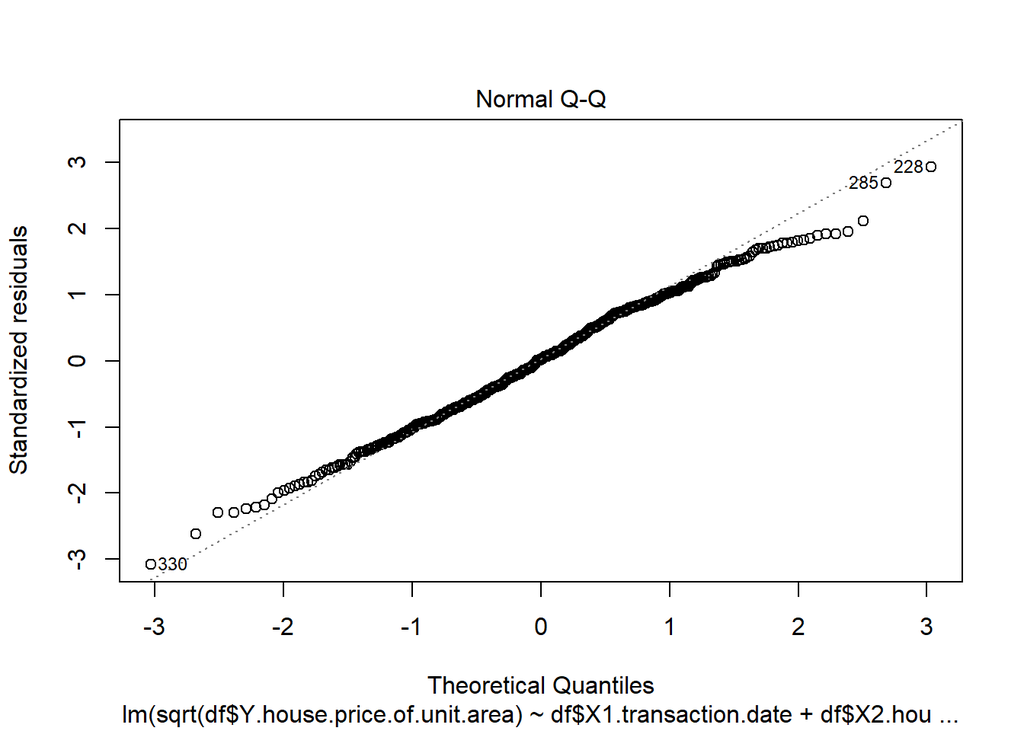

```r
plot(M3,2)
```

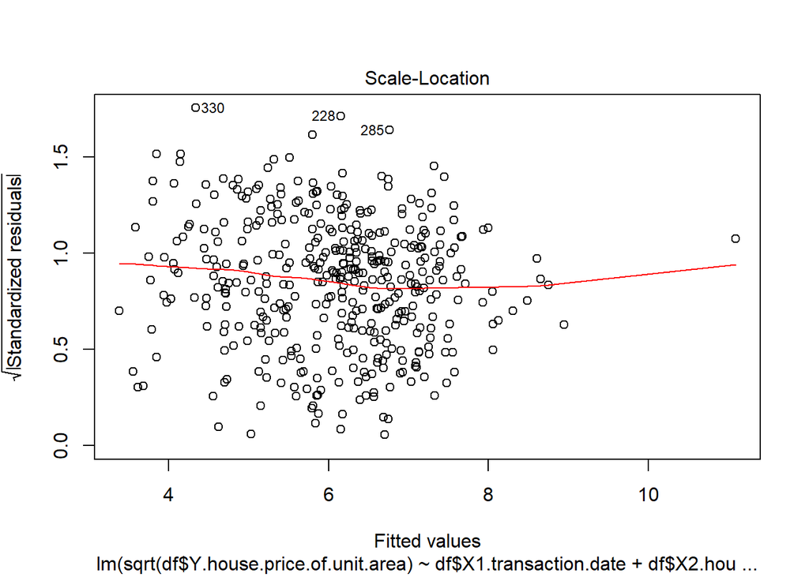

```r
plot(M3,3)
```

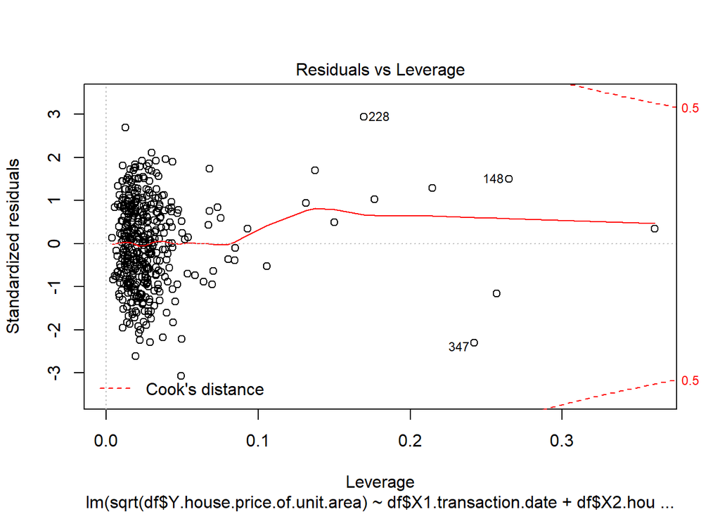

```r
plot(M3,5)
```

```r
AIC(M0)
```

```
## [1] 48.47725
```

```r
AIC(M1)
```

```
## [1] 47.09298
```

```r
AIC(M2)
```

```
## [1] 48.39733
```

```r
AIC(M3)
```

```
## [1] 46.48114
```

```r
BIC(M0)
```

```
## [1] 104.8055
```

```r
BIC(M1)
```

```
## [1] 95.37435
```

```r
BIC(M2)
```

```
## [1] 88.63181
```

```r
BIC(M3)
```

```
## [1] 98.78596
```

Because AIC does not punish the irrelevant variables very hard, we do not judge the four models by AIC. So, BIC is our way of testing the model. Finally, we use t test and ANOVA to test the final model.

step 5 ANOVA

```r
anova(M2)
```

```
## Analysis of Variance Table
##
## Response: sqrt(df$Y.house.price.of.unit.area)
##                                                           Df  Sum Sq Mean Sq
## df$X1.transaction.date                                     1   3.861   3.861
## df$X2.house.age                                            1  22.069  22.069
## df$X3.distance.to.the.nearest.MRT.station                  1 275.606 275.606
## df$X4.number.of.convenience.stores                         1  23.387  23.387
## df$X5.latitude                                             1  15.537  15.537
## df$X7.distance.to.nearest.School                           1 142.268 142.268
## df$X3.distance.to.the.nearest.MRT.station:df$X5.latitude   1   0.201   0.201
## df$X5.latitude:df$X7.distance.to.nearest.School            1   0.525   0.525
## Residuals                                                404  25.902   0.064
##                                                            F value    Pr(>F)
## df$X1.transaction.date                                     60.2251 6.997e-14
## df$X2.house.age                                           344.2204 < 2.2e-16
## df$X3.distance.to.the.nearest.MRT.station                4298.6496 < 2.2e-16
## df$X4.number.of.convenience.stores                        364.7739 < 2.2e-16
## df$X5.latitude                                            242.3339 < 2.2e-16
## df$X7.distance.to.nearest.School                         2218.9628 < 2.2e-16
## df$X3.distance.to.the.nearest.MRT.station:df$X5.latitude    3.1341   0.07743
## df$X5.latitude:df$X7.distance.to.nearest.School             8.1906   0.00443
## Residuals
##
## df$X1.transaction.date                                   ***
## df$X2.house.age                                          ***
## df$X3.distance.to.the.nearest.MRT.station                ***
## df$X4.number.of.convenience.stores                       ***
## df$X5.latitude                                           ***
## df$X7.distance.to.nearest.School                         ***
## df$X3.distance.to.the.nearest.MRT.station:df$X5.latitude .
## df$X5.latitude:df$X7.distance.to.nearest.School          **
## Residuals
## ---
## Signif. codes:  0 '***' 0.001 '**' 0.01 '*' 0.05 '.' 0.1 ' ' 1
```

After ANOVA test only one p-value of the interaction variable is a little bit larger than 0.05. So M2 is a good model to explain which and how the factors influence house price per unit.